# Easy_Visa_Fullcode_Project

### XGBoost Classifier

```python
xgb_classifier = XGBClassifier(
    random_state=1, eval_metric="logloss"
)  # define XGBoost Classifier with random state = 1 and eval_metric="logloss"
xgb_classifier.fit(X_train, y_train)  # fit XGBoost Classifier on the train data
```

```
XGBClassifier(base_score=None, booster=None, callbacks=None,
              colsample_bylevel=None, colsample_bynode=None,
              colsample_bytree=None, early_stopping_rounds=None,
              enable_categorical=False, eval_metric='logloss',
              feature_types=None, gamma=None, gpu_id=None, grow_policy=None,
              importance_type=None, interaction_constraints=None,
              learning_rate=None, max_bin=None, max_cat_threshold=None,
              max_cat_to_onehot=None, max_delta_step=None, max_depth=None,
              max_leaves=None, min_child_weight=None, missing=nan,
              monotone_constraints=None, n_estimators=100, n_jobs=None,
              num_parallel_tree=None, predictor=None, random_state=1, ...)
```

#### Checking model performance on training set

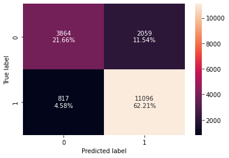

```python
confusion_matrix_sklearn(
    xgb_classifier, X_train, y_train
)  # create confusion matrix for train data
```

```python
xgb_classifier_model_train_perf = model_performance_classification_sklearn(
    xgb_classifier, X_train, y_train
)  # performance on train data
xgb_classifier_model_train_perf
```

|  | Accuracy | Recall | Precision | F1 |
| --- | --- | --- | --- | --- |
| 0 | 0.838753 | 0.931419 | 0.843482 | 0.885272 |

#### Checking model performance on test set

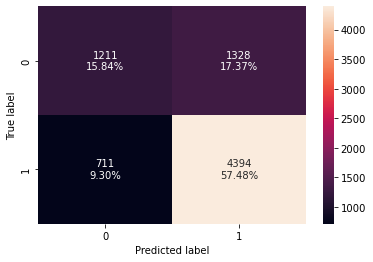

```python
confusion_matrix_sklearn(
    xgb_classifier, X_test, y_test
)  # create confusion matrix for test data
```

```python
xgb_classifier_model_test_perf = model_performance_classification_sklearn(
    xgb_classifier, X_test, y_test
)  # performance for test data
xgb_classifier_model_test_perf
```

|  | Accuracy | Recall | Precision | F1 |
| --- | --- | --- | --- | --- |
| 0 | 0.733255 | 0.860725 | 0.767913 | 0.811675 |

- The model is overfitting on the test data.

### Hyperparameter Tuning - XGBoost Classifier

```python
# Choose the type of classifier.
xgb_tuned = XGBClassifier(random_state=1, eval_metric="logloss")

# Grid of parameters to choose from
parameters = {
    "n_estimators": np.arange(150, 250, 50),
    "scale_pos_weight": [1, 2],
    "subsample": [0.9, 1],
    "learning_rate": np.arange(0.1, 0.21, 0.1),
    "gamma": [3, 5],
    "colsample_bytree": [0.8, 0.9],
    "colsample_bylevel": [0.9, 1],
}

# Type of scoring used to compare parameter combinations
acc_scorer = metrics.make_scorer(metrics.f1_score)

# Run the grid search
grid_obj = GridSearchCV(
    xgb_tuned, parameters, scoring=acc_scorer, cv=5
)  ## run grid search with cv = 5
grid_obj = grid_obj.fit(X_train, y_train)  # fit the grid_obj on train data

# Set the clf to the best combination of parameters
xgb_tuned = grid_obj.best_estimator_

# Fit the best algorithm to the data.
xgb_tuned.fit(X_train, y_train)
```

```
XGBClassifier(base_score=None, booster=None, callbacks=None,
              colsample_bylevel=1, colsample_bynode=None, colsample_bytree=0.9,
              early_stopping_rounds=None, enable_categorical=False,
              eval_metric='logloss', feature_types=None, gamma=5, gpu_id=None,
              grow_policy=None, importance_type=None,
              interaction_constraints=None, learning_rate=0.1, max_bin=None,
              max_cat_threshold=None, max_cat_to_onehot=None,
              max_delta_step=None, max_depth=None, max_leaves=None,
              min_child_weight=None, missing=nan, monotone_constraints=None,
              n_estimators=200, n_jobs=None, num_parallel_tree=None,
              predictor=None, random_state=1, ...)
```

#### Checking model performance on training set

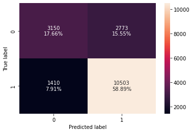

```python
confusion_matrix_sklearn(
    xgb_tuned, X_train, y_train
)  # create confusion matrix for train data on tuned estimator
```

```python
xgb_tuned_model_train_perf = model_performance_classification_sklearn(
    xgb_tuned, X_train, y_train
)  # performance for train data on tuned estimator
xgb_tuned_model_train_perf
```

|  | Accuracy | Recall | Precision | F1 |
| --- | --- | --- | --- | --- |
| 0 | 0.765474 | 0.881642 | 0.791127 | 0.833935 |

#### Checking model performance on test set

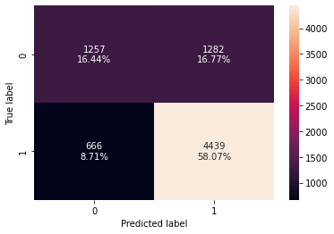

```python
confusion_matrix_sklearn(
    xgb_tuned, X_test, y_test
)  # create confusion matrix for test data on tuned estimator
```

```python
xgb_tuned_model_test_perf = model_performance_classification_sklearn(
    xgb_tuned, X_test, y_test
)  ##  performance for test data on tuned estimator
xgb_tuned_model_test_perf
```

|  | Accuracy | Recall | Precision | F1 |
| --- | --- | --- | --- | --- |
| 0 | 0.74516 | 0.86954 | 0.775913 | 0.820063 |

- The performance of the model on the test data has improved. There are no significant indications of overfitting.

### Stacking Classifier

```python
estimators = [
    ("AdaBoost", ab_classifier),
    ("Gradient Boosting", gbc_tuned),
    ("Random Forest", rf_tuned),
]

final_estimator = xgb_tuned

stacking_classifier = StackingClassifier(
    estimators=estimators, final_estimator=final_estimator
)  ## define Stacking Classifier

stacking_classifier.fit(X_train, y_train)  ## fit Stacking Classifier on the train data
```

```
StackingClassifier(estimators=[('AdaBoost', AdaBoostClassifier(random_state=1)),
                               ('Gradient Boosting',
                                GradientBoostingClassifier(init=AdaBoostClassifier(random_state=1),
                                                           max_features=0.8,
                                                           n_estimators=200,
                                                           random_state=1,
                                                           subsample=1)),
                               ('Random Forest',
                                RandomForestClassifier(max_depth=10,
                                                       max_features='sqrt',
                                                       min_samples_split=7,
                                                       n_estimators=20,
                                                       oob_score=Tru...
                                                 gpu_id=None, grow_policy=None,
                                                 importance_type=None,
                                                 interaction_constraints=None,
                                                 learning_rate=0.1,
                                                 max_bin=None,
                                                 max_cat_threshold=None,
                                                 max_cat_to_onehot=None,
                                                 max_delta_step=None,
                                                 max_depth=None,
                                                 max_leaves=None,
                                                 min_child_weight=None,
                                                 missing=nan,
                                                 monotone_constraints=None,
                                                 n_estimators=200, n_jobs=None,
                                                 num_parallel_tree=None,
                                                 predictor=None, random_state=1, ...))
```

#### Checking model performance on training set

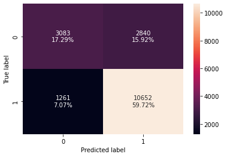

```python
confusion_matrix_sklearn(
    stacking_classifier, X_train, y_train
)  # create confusion matrix for train data
```

```python
stacking_classifier_model_train_perf = model_performance_classification_sklearn(
    stacking_classifier, X_train, y_train
)  # performance on train data
stacking_classifier_model_train_perf
```

|  | Accuracy | Recall | Precision | F1 |
| --- | --- | --- | --- | --- |
| 0 | 0.770072 | 0.894149 | 0.789505 | 0.838575 |

#### Checking model performance on test set

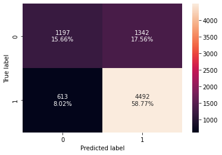

```python
confusion_matrix_sklearn(
    stacking_classifier, X_test, y_test
)  # create confusion matrix for test data
```

```python
stacking_classifier_model_test_perf = model_performance_classification_sklearn(
    stacking_classifier, X_test, y_test
)  ##  performance for test data
stacking_classifier_model_test_perf
```

|  | Accuracy | Recall | Precision | F1 |
| --- | --- | --- | --- | --- |
| 0 | 0.744244 | 0.879922 | 0.769969 | 0.821282 |

- Model does not perform extremely well on test data.
- The slight disparity in F1 scores indicate slight overfitting.

### Model Performance Comparison and Final Model Selection

```python
# training performance comparison

models_train_comp_df = pd.concat(
    [
        decision_tree_perf_train.T,
        dtree_estimator_model_train_perf.T,
        bagging_classifier_model_train_perf.T,
        bagging_estimator_tuned_model_train_perf.T,
        rf_estimator_model_train_perf.T,
        rf_tuned_model_train_perf.T,
        ab_classifier_model_train_perf.T,
        abc_tuned_model_train_perf.T,
        gb_classifier_model_train_perf.T,
        gbc_tuned_model_train_perf.T,
        xgb_classifier_model_train_perf.T,
        xgb_tuned_model_train_perf.T,
        stacking_classifier_model_train_perf.T,
    ],
    axis=1,
)  # plot the list adjacent to each other
models_train_comp_df.columns = [
    "Decision Tree",
    "Tuned Decision Tree",
    "Bagging Classifier",
    "Tuned Bagging Classifier",
    "Random Forest",
    "Tuned Random Forest",
    "Adaboost Classifier",
    "Tuned Adaboost Classifier",
    "Gradient Boost Classifier",
    "Tuned Gradient Boost Classifier",
    "XGBoost Classifier",
    "XGBoost Classifier Tuned",
    "Stacking Classifier",
]
print("Training performance comparison:")  # print statement
models_train_comp_df
```

```
Training performance comparison:
```

|  | Decision Tree | Tuned Decision Tree | Bagging Classifier | Tuned Bagging Classifier | Random Forest | Tuned Random Forest | Adaboost Classifier | Tuned Adaboost Classifier | Gradient Boost Classifier | Tuned Gradient Boost Classifier | XGBoost Classifier | XGBoost Classifier Tuned | Stacking Classifier |
| --- | --- | --- | --- | --- | --- | --- | --- | --- | --- | --- | --- | --- | --- |
| Accuracy | 1.0 | 0.712548 | 0.985198 | 0.996187 | 1.0 | 0.769119 | 0.738226 | 0.718995 | 0.758802 | 0.764017 | 0.838753 | 0.765474 | 0.770072 |
| Recall | 1.0 | 0.931923 | 0.985982 | 0.999916 | 1.0 | 0.918660 | 0.887182 | 0.781247 | 0.883740 | 0.882649 | 0.931419 | 0.881642 | 0.894149 |
| Precision | 1.0 | 0.720067 | 0.991810 | 0.994407 | 1.0 | 0.776556 | 0.760688 | 0.794587 | 0.783042 | 0.789059 | 0.843482 | 0.791127 | 0.789505 |
| F1 | 1.0 | 0.812411 | 0.988887 | 0.997154 | 1.0 | 0.841652 | 0.819080 | 0.787861 | 0.830349 | 0.833234 | 0.885272 | 0.833935 | 0.838575 |

```python
# testing performance comparison

models_test_comp_df = pd.concat(
    [
        decision_tree_perf_test.T,
        dtree_estimator_model_test_perf.T,
        bagging_classifier_model_test_perf.T,
        bagging_estimator_tuned_model_test_perf.T,
        rf_estimator_model_test_perf.T,
        rf_tuned_model_test_perf.T,
        ab_classifier_model_test_perf.T,
        abc_tuned_model_test_perf.T,
        gb_classifier_model_test_perf.T,
        gbc_tuned_model_test_perf.T,
        xgb_classifier_model_test_perf.T,
        xgb_tuned_model_test_perf.T,
        stacking_classifier_model_test_perf.T,
    ],
    axis=1,
)  # plot the list adjacent to each other
models_test_comp_df.columns = [
    "Decision Tree",
    "Tuned Decision Tree",
    "Bagging Classifier",
    "Tuned Bagging Classifier",
    "Random Forest",
    "Tuned Random Forest",
    "Adaboost Classifier",
    "Tuned Adaboost Classifier",
    "Gradient Boost Classifier",
    "Tuned Gradient Boost Classifier",
    "XGBoost Classifier",
    "XGBoost Classifier Tuned",
    "Stacking Classifier",
]
print("Testing performance comparison:")  # print statement
models_test_comp_df
```

```
Testing performance comparison:
```

|  | Decision Tree | Tuned Decision Tree | Bagging Classifier | Tuned Bagging Classifier | Random Forest | Tuned Random Forest | Adaboost Classifier | Tuned Adaboost Classifier | Gradient Boost Classifier | Tuned Gradient Boost Classifier | XGBoost Classifier | XGBoost Classifier Tuned | Stacking Classifier |
| --- | --- | --- | --- | --- | --- | --- | --- | --- | --- | --- | --- | --- | --- |
| Accuracy | 0.664835 | 0.706567 | 0.691523 | 0.724228 | 0.727368 | 0.738095 | 0.734301 | 0.716510 | 0.744767 | 0.743459 | 0.733255 | 0.745160 | 0.744244 |
| Recall | 0.742801 | 0.930852 | 0.764153 | 0.895397 | 0.847209 | 0.898923 | 0.885015 | 0.781391 | 0.876004 | 0.871303 | 0.860725 | 0.869540 | 0.879922 |
| Precision | 0.752232 | 0.715447 | 0.771711 | 0.743857 | 0.768343 | 0.755391 | 0.757799 | 0.791468 | 0.772366 | 0.773296 | 0.767913 | 0.775913 | 0.769969 |
| F1 | 0.747487 | 0.809058 | 0.767913 | 0.812622 | 0.805851 | 0.820930 | 0.816481 | 0.786397 | 0.820927 | 0.819379 | 0.811675 | 0.820063 | 0.821282 |

- The Tuned Decision Tree, AdaBoost Classifier(default and tuned), Gradient boost and Stacking Classifier models show the least overfitting on the test data set per their F1 scores.
- Of these, the Stacking Classifier and the Gradient Boost classifier have the highest F1 scores on the test data but the stacking classifier shows greater disparity between the two metric values so we will select the gradient boost classifier.

### Important features of the final model

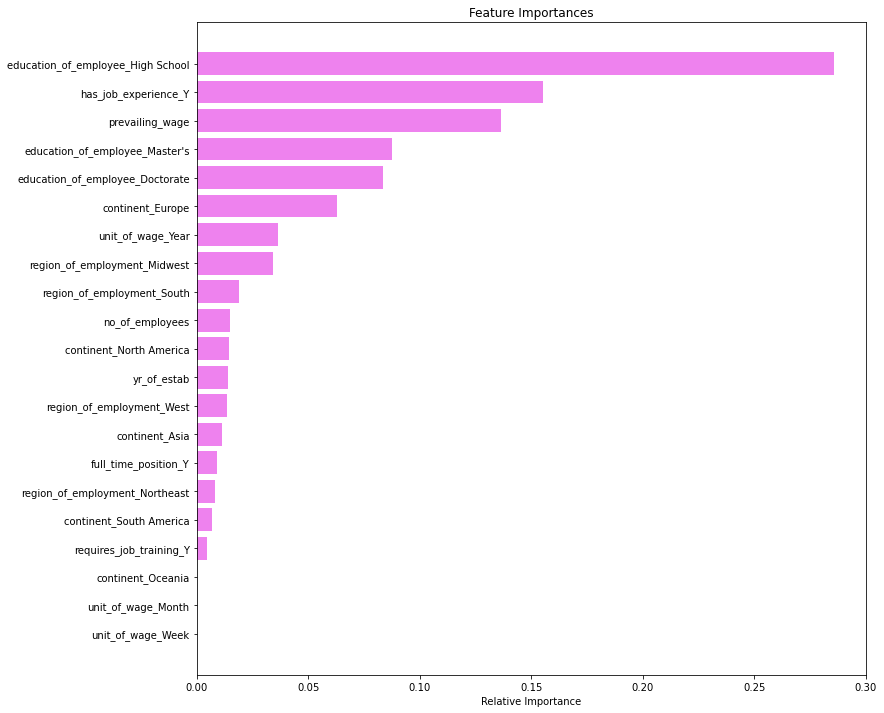

```python
feature_names = X_train.columns  # independent columns in the train dataset
importances = (
    gb_classifier.feature_importances_
)  # important features per the gradient boost classifier
indices = np.argsort(importances)  # order of importance of features

plt.figure(figsize=(12, 12))  # size configuration
plt.title("Feature Importances")  # Title of the plot
plt.barh(
    range(len(indices)), importances[indices], color="violet", align="center"
)  # create horizontal barplot
plt.yticks(
    range(len(indices)), [feature_names[i] for i in indices]
)  # set the current tick locations and labels of the y-axis
plt.xlabel("Relative Importance")  # x axis label
plt.show()  # plot graph
```

Using the Gradient Boost classifier as our model:

- A high school qualification is significantly the most important factor in determining the visa certification status of an employee.
- Some amount of job experience is also significantly needed to secure a certified visa.
- An employee with a masters and/or doctorate degree also has a good chance of securing a certified visa.
- European employees seems to stand a better chance of securing a visa compared to employees from other continents.
- Employees who earn a yearly wage are more likely to obtain a certified visa than those on the other units of wage.
- Employees in the midwest also have greater probability of securing a visa than their counterparts in other regions.

### Data Insights

- Using the Gradient Boost classifier as our model; A high school qualification is significantly the most important factor in determining the visa certification status of an employee; Some amount of job experience is also significantly needed to secure a certified visa; An employee with a masters and/or doctorate degree also has a good chance of securing a certified visa; European employees seems to stand a better chance of securing a visa compared to employees from other continents; Employees who earn a yearly wage are more likely to obtain a certified visa than those on the other units of wage and Employees in the midwest also have greater probability of securing a visa than their counterparts in other regions.
- Employees who do not have a full time job mostly earn a yearly wage
- Employees who have a certified visa earn have a higher mean prevailing wage than those denied.
- The Island has the mean number of employees ; closely trailed by the West and NorthEast.
- Doctorate degree holders have the highest count of employees with a full time job.
- Employees with a masters education have the highest mean prevailing wage. Doctorate degree holders have the least mean prevailing wage but this could be due to the relative count of employees in that category.
- The West has the most employees with a doctorate degree and the South has the most employees with a bachelor's and masters degree.
- Generally though, employees with bachelor degree were the group with the most count who required job training.
- The european employees are the most paid in the yearly unit wage category with the asians and africans trailing closely.
- Africa, Asia and North America are the top three continents with the highest mean prevailing wage. These three continents also had the highest average number of employees so could explain why they top this distribution too.
- The top three continents with average number of employees are: North America, Africa and Asia respectively.
- Even though Africa has the least number of employees with a Bachelor's degree, it has the most employees with a Master's degree.
- Europe has the most employees with doctorate degrees while Asia has the least.
- Oceania has the most nummber of employees with high school qualification.
- The Midwest and Island have the highest mean salary amongst all the different regions in the US.
- The mean salary of employees with certified visas is slightly greater than the salary of employees with denied visas. This slight difference,however, is not enough to draw a conclusion on their correlation.
- Even though Europe has more employees with certified visas, Asia has more employees with more advanced levels of education hence we cannot incisively attribute Europe's high visa certifications to advanced level of education
- Europe has the most number of employees with certified visas and the least number of employees with denied visas.
- The Midwest has the most number of employees with certified visas while the Island region has the most number of employees with the most denied visas.
- South America has the most number of employees with denied visas.
- The top five establishment years are 1998,2005,2001,2007 and 1999 respectively
- More than 66% of employees have a certified visa while about 33.2% were denied one.
- At least 90% of employees use the yearly unit of wage while less than 1% use the monthly option.
- Out of the five regions under consideration, Northeast,South and West respectively represent the top three regions with the highest number of employees with more than 25% each.
- The island region has the least count with only 1.5%.
- At least 88% of employees do not require any job training.
- More than 50% of employees have some job experience.
- About 40% of employees have a Bachelors degree; 37.8% have a Masters degree; 13.4% a high school qualification and 8.6% a doctorate degree
- 50% of employees earn less than the average prevailing wage.